# Split-ORF Report

14 April 2021

This report shows a number of summary statistics of the a result file obtained from the SplitOrfs software.

## Overview of the valid alignment results:

```
##                                       Entry Values
## 1                     Number of transcripts  20024
## 2                Transcripts with >= 2 ORFs   4528
## 3 Transcripts with >= 1 PFAM domain overlap   1594
## 4                    Number of unique Genes   2715
```

## Histogramm of matching ORFs per transcripts:

[output not shown]

[output cut: 174 more lines]

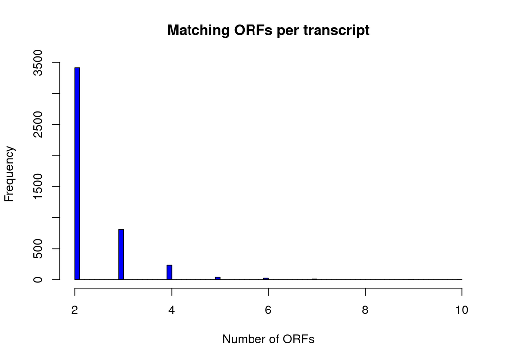

## Histogramm of NMD-protein pairs

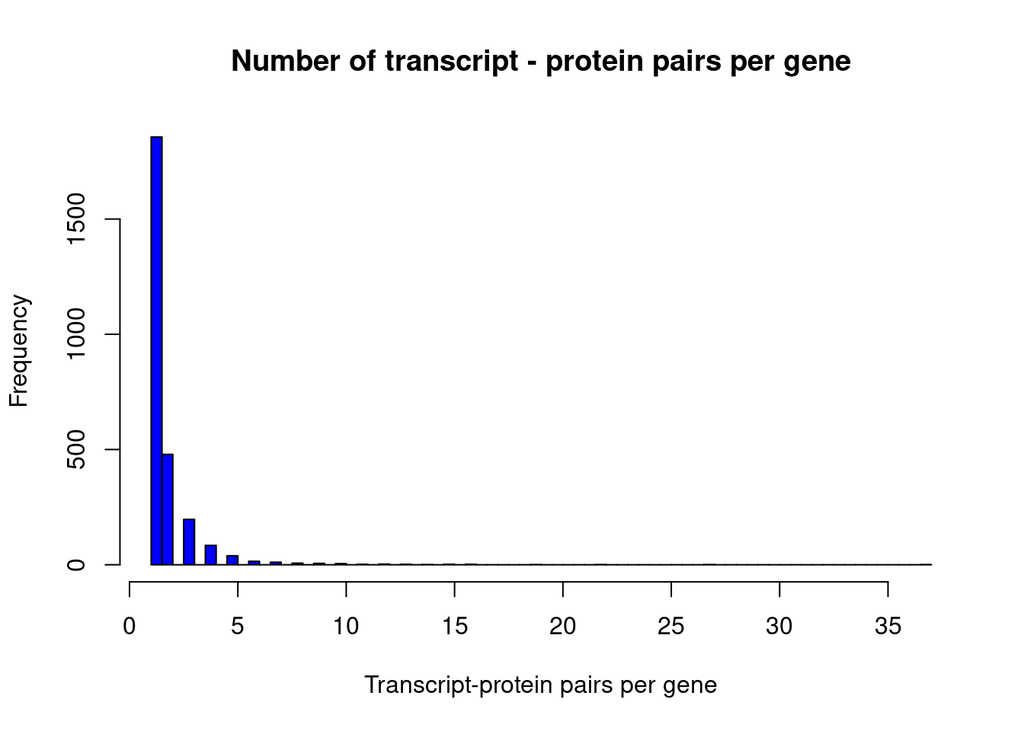

## Top 20 genes, that have the most transcripts with >=2 ORFs

```
##              geneIDs frequency
## 1470 ENSG00000158864        37
## 1262 ENSG00000145020        27
## 1948 ENSG00000178035        22
## 466  ENSG00000103811        19
## 175  ENSG00000070061        16
## 1019 ENSG00000135047        16
## 2171 ENSG00000197102        15
## 2193 ENSG00000197912        15
## 152  ENSG00000064601        14
## 823  ENSG00000123815        13
## 928  ENSG00000130816        13
## 2    ENSG00000001497        12
## 311  ENSG00000090621        12
## 1293 ENSG00000147140        12
## 587  ENSG00000108654        11
## 2135 ENSG00000188603        11
## 204  ENSG00000073584        10
## 279  ENSG00000087053        10
## 325  ENSG00000092108        10
## 684  ENSG00000114388        10
```

## Histogramm of min and max sequence identity

A histogramm of min and max sequence identity values from the ORF-protein alignments, i.e., each such value is derived from one ORF-protein alignment. For all ORFs of a protein-ORF match the min respectively max seq. identity is recorded. The minimal sequence identity allowed for an alignment by default is 95%.

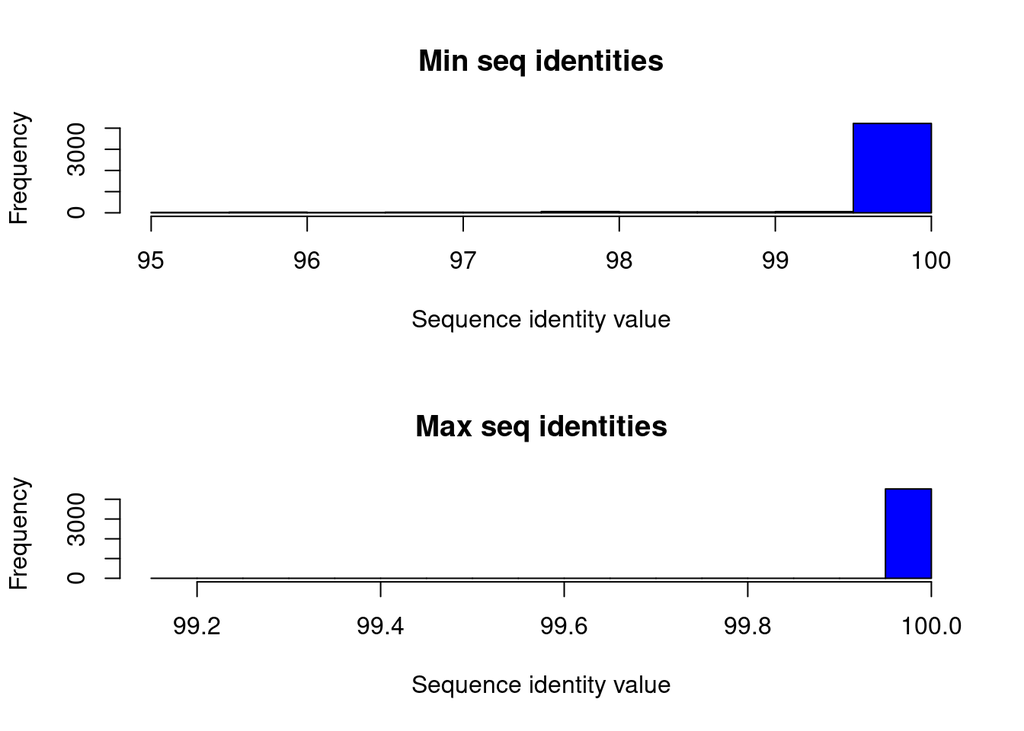

## Histogram in the intervall [0,2000]

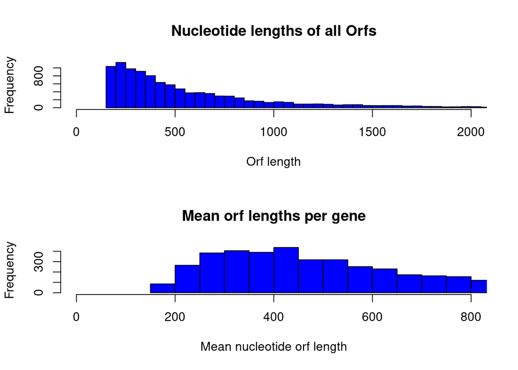

## PFAM domain annotations

PFAM domain annotations were obtained for all protein coding genes. Here we show how often more than one ORF overlaps an annotated PFAM domain in the alignment region. For example a value of two means, that two distinct ORFs made from the transcript aligned to regions in the protein that overlapped PFAM annotations.

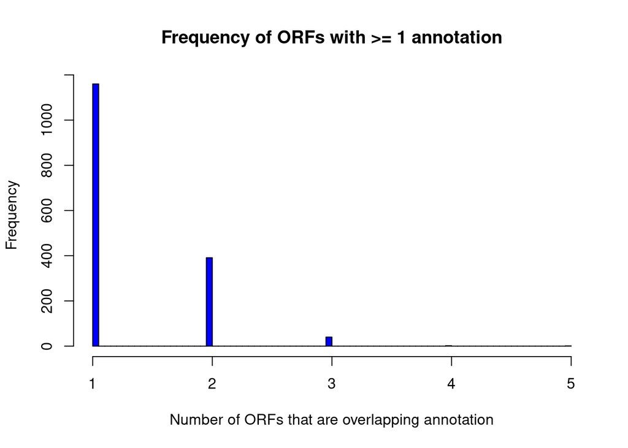

## Top 20 genes that have the most transcripts ORFs with annotations per transcript

```
##               geneID      OrfTransID NumORFAnnot
## 1009 ENSG00000101203 ENST00000479501           5
## 15   ENSG00000149136 ENST00000293880           4
## 149  ENSG00000178038 ENST00000431015           4
## 98   ENSG00000054654 ENST00000394768           3
## 157  ENSG00000203710 ENST00000434033           3
## 161  ENSG00000203710 ENST00000436595           3
## 193  ENSG00000178038 ENST00000450172           3
## 194  ENSG00000203710 ENST00000450439           3
## 208  ENSG00000135596 ENST00000456101           3
## 252  ENSG00000090539 ENST00000460627           3
## 258  ENSG00000149243 ENST00000460787           3
## 265  ENSG00000164896 ENST00000460980           3
## 354  ENSG00000099994 ENST00000463101           3
## 360  ENSG00000082458 ENST00000463252           3
```

[output cut: 27 more lines]

## Domain analysis

Number of different Domain annotations found in Split ORFs.

```
## [1] 832
```

Analysis of the type of domains that are part of SplitORFs looking per gene, this avoids counting similar transcripts from the same gene.

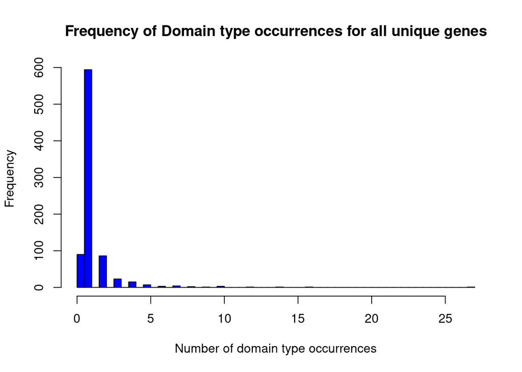

Show the top 50 most frequent domains found in Split Orfs (counting once per gene).

```
##
##         PF00400         PF07654         PF13895         PF00271         PF00076
##              27              16              14              12              10
##         PF00270         PF00969         PF00856         PF00105 PF00993,PF07654
##              10              10               9               8               8
##         PF00069         PF00096 PF00271,PF00270         PF13516 PF00076,PF00076
##               7               7               7               7               6
##         PF08264         PF15975 PF00400,PF00400         PF00531 PF00595,PF00595
##               6               6               5               5               5
## PF00788,PF00617         PF06623         PF14604         PF17035         PF00018
##               5               5               5               5               4
##         PF00053 PF00096,PF01352         PF00153         PF00163         PF00168
##               4               4               4               4               4
## PF00168,PF00168         PF00433         PF00520         PF00595         PF00615
##               4               4               4               4               4
##         PF00627         PF00628         PF07810         PF15070         PF00010
##               4               4               4               4               3
## PF00013,PF00013         PF00023         PF00046         PF00059 PF00096,PF00096
##               3               3               3               3               3
## PF00168,PF07002 PF00169,PF00169         PF00397         PF00415         PF00622
##               3               3               3               3               3
```

Analysis of the type of domains that are part of SplitORFs looking at all transcripts, this incorporates also the case that two transcripts may come from the same gene.

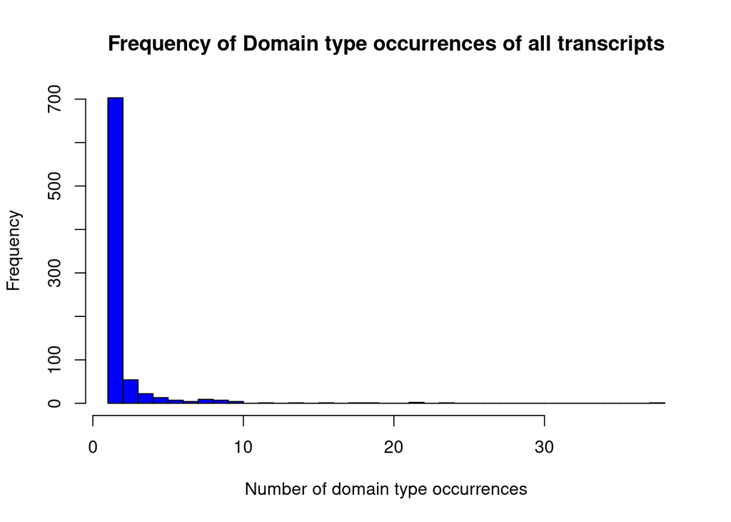

Show the top 50 most frequent domains found in Split Orfs (counting all transcripts).

```
##
##         PF00400         PF00076         PF00271         PF00571         PF07654
##              38              24              22              22              19
##         PF00270         PF13895         PF15070         PF08669 PF00076,PF00076
##              18              16              14              12              10
##         PF00622         PF00969         PF13516         PF00004         PF00018
##              10              10              10               9               9
##         PF00069 PF00400,PF00400         PF00505         PF00856         PF04031
##               9               9               9               9               9
##         PF00096         PF00105         PF00168         PF00531         PF00993
##               8               8               8               8               8
## PF00993,PF07654         PF02893 PF08061,PF00270 PF08669,PF08669 PF00271,PF00270
##               8               8               8               8               7
##         PF00627         PF03109         PF17035         PF00059         PF00595
##               7               7               7               6               6
##         PF00617         PF02985         PF07527         PF08264         PF15975
##               6               6               6               6               6
##         PF00046         PF00053         PF00153         PF00520 PF00595,PF00595
##               5               5               5               5               5
##         PF00628 PF00788,PF00617         PF03144         PF06623         PF07647
##               5               5               5               5               5
```

This document was created with R Markdown and the Knit package. Markdown is a simple formatting syntax for authoring HTML, PDF, and MS Word documents. For more details on using R Markdown see http://rmarkdown.rstudio.com.